# Evidence 2

José Gabriel Usiña Mogro

2022-09-11

# a) Introduction

Time series analysis helps to analyze the dynamic change that a variable suffer with the pass of the time. For this type of analysis we use Time Series Data. As Tableau page says, Time series analysis is analyze a sequence of data collected over a interval of time. (Tableau)

# b) Background

Nowadays, household is increasing eacht time. According to Passport, “*The number of households in Mexico is anticipated to expand by 16.9% over the forecast period, reaching 42.5 million by 2040*”(Euromonitor International, 2022). If we look at the indicador **Household credit**, this indicator has increase a lot in the last 6 months according to the Global Economy (Mexico Household credit, billion currency units, June, 2022 - data, chart, s. f.). Both of them mean that household credit is going to increase more, in order that credit and number of household will increase, so we can expect a big increase.

# c) Description of the Problem Situation

The Problem Situation tell us about Financiera Ma, a financial company that provides services of credit card in Mexico. The problem is that the use of credit card is not going so good as they expected at the beginning of the year. In this case they compare the use of credit card with countries like Argentina or Brazil, and we can see that there is a big difference between them.

In this case we need to know how the credit in the household changes with the time, this is related with the use of credit card because householders will need more ways to use credit, and credit cards is one of them.

# d) Data and methodology

```r
data_ev<-read_excel("ev2_data.xlsx")
```

## Describe dataset

```r
str(data_ev)
```

```
## tibble [109 x 7] (S3: tbl_df/tbl/data.frame)
##  $ date                : POSIXct[1:109], format: "1994-12-01" "1995-01-01" ...
##  $ credit_to_households: num [1:109] 191 211 231 251 272 ...
##  $ inflation_rate      : num [1:109] 7.05 3.76 23.66 37.88 51.97 ...
##  $ gdp_growth          : num [1:109] 5.15 -1.49 -9.07 -7.54 -6.89 ...
##  $ unemployment        : num [1:109] NA NA NA NA NA NA NA NA NA NA ...
##  $ consumer_confidence : num [1:109] NA NA NA NA NA NA NA NA NA NA ...
##  $ remittances         : num [1:109] NA 169 197 237 178 ...
```

```r
summary(data_ev)
```

```
##       date                     credit_to_households inflation_rate
##  Min.   :1994-12-01 00:00:00   Min.   : 190.5       Min.   :-0.170
##  1st Qu.:2001-08-01 00:00:00   1st Qu.: 544.2       1st Qu.: 0.940
##  Median :2008-04-01 00:00:00   Median :1635.7       Median : 2.130
##  Mean   :2008-04-24 06:09:54   Mean   :1745.0       Mean   : 4.408
##  3rd Qu.:2015-01-01 00:00:00   3rd Qu.:2648.7       3rd Qu.: 4.080
##  Max.   :2021-12-01 00:00:00   Max.   :4271.0       Max.   :51.970
##
##    gdp_growth       unemployment   consumer_confidence  remittances
##  Min.   :-18.622   Min.   :2.770   Min.   :28.67       Min.   : 169.2
##  1st Qu.:  1.117   1st Qu.:3.509   1st Qu.:37.23       1st Qu.: 425.0
##  Median :  2.713   Median :4.052   Median :39.63       Median : 823.7
##  Mean   :  2.041   Mean   :4.218   Mean   :39.66       Mean   : 753.5
##  3rd Qu.:  4.095   3rd Qu.:4.894   3rd Qu.:42.64       3rd Qu.: 955.7
##  Max.   : 19.901   Max.   :6.146   Max.   :47.69       Max.   :1738.9
##                    NA's   :41      NA's   :26          NA's   :1
```

We need to clean the data set first. We have some NA’s in some of the variables, Date already in Date format, but not the typicall, so anyway I will change it

**NA’s** We are going to delet all of the observations with NA

```r
data_ev<-data_ev%>%
  filter(unemployment>0)
```

**Date**

```r
data_ev$date<-as.Date(data_ev$date)
```

Transforming to time series format

```r
credits<-ts(data_ev$credit_to_households,frequency = 4,start = c(2005,1))
```

## Plot

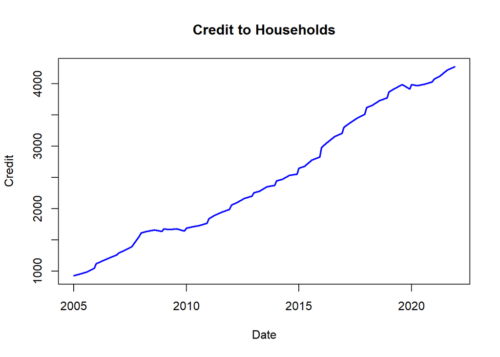

```r
plot(data_ev$date,data_ev$credit_to_households, type="l",col="blue", lwd=2, xlab ="Date",ylab ="Credit", main = "Credit to Households")
```

## Decomposing

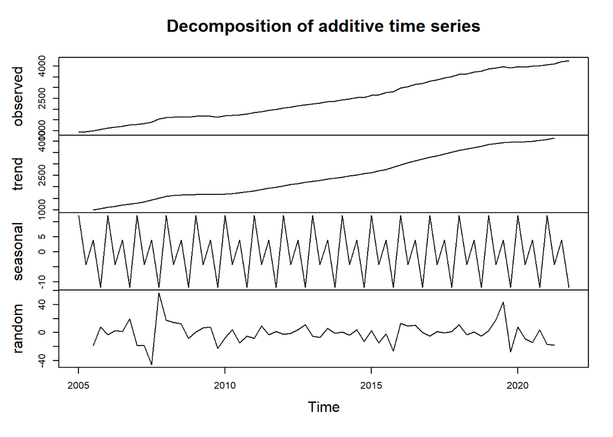

```r
credit_dec<-decompose(credits)
plot(credit_dec)
```

## Stationary test

```r
adf.test(credits)
```

```
##
##  Augmented Dickey-Fuller Test
##
## data:  credits
## Dickey-Fuller = -2.078, Lag order = 4, p-value = 0.5435
## alternative hypothesis: stationary
```

```r
#Ho: Non-stationary
#Ha: Stationary
```

The p-values is greater than 0.05. We fail to reject the H0. The time series data is non-stationary

## Serial Autocorrelation

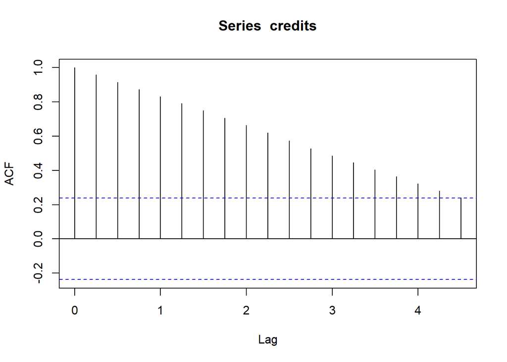

```r
acf(credits)
```

We can observer that there is serial autocorrelation

```r
Box.test(data_ev$credit_to_households,lag=1,type="Ljung-Box")
```

```
##
##  Box-Ljung test
##
## data:  data_ev$credit_to_households
## X-squared = 65.241, df = 1, p-value = 6.661e-16
```

```r
#Ho: No Serial Correlation
#Ha: Serial Correlation
```

p-value <0.05. Reject Null Hypothesis. There is serial autocorrelation

## Seasonal adjustment

We could observe seasonal in our time serie data, so we need to make a seasonal adjustment

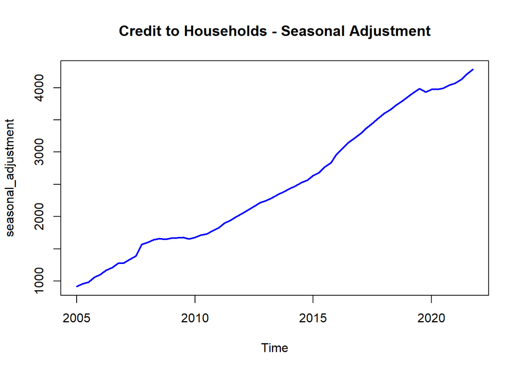

```r
seasonal_adjustment = credits - credit_dec$seasonal
plot(seasonal_adjustment,type="l",col="blue",lwd=2,main="Credit to Households - Seasonal Adjustment")
```

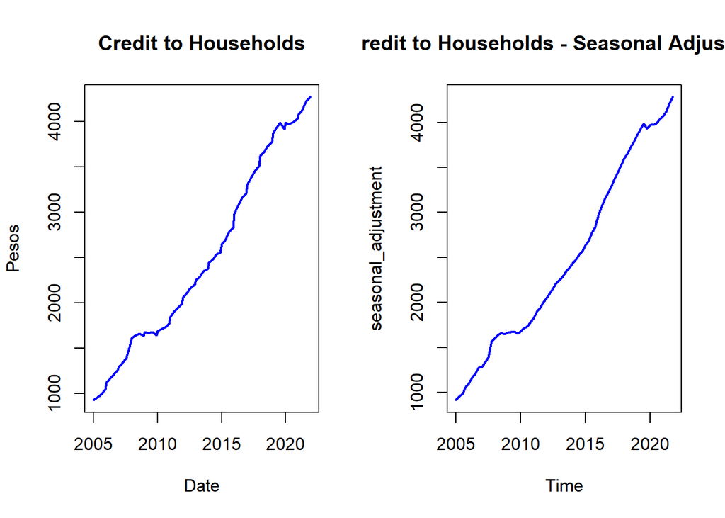

```r
par(mfrow=c(1,2))
plot(data_ev$date,data_ev$credit_to_households, type="l",col="blue", lwd=2, xlab ="Date",ylab ="Pesos", main = "Credit to Households")
plot(seasonal_adjustment,type="l",col="blue",lwd=2,main="Credit to Households - Seasonal Adjustment")
```

We can observe the seasonal adjustment, but I decided to not consider it for the estimations

# Time Series Regression Analysis

## Time Series Model 1

### Model 1 (ARMA 1,1)

```r
summary(ARMA.credit<-arma(data_ev$credit_to_households, order=c(1,1)))
```

```
##
## Call:
## arma(x = data_ev$credit_to_households, order = c(1, 1))
##
## Model:
## ARMA(1,1)
##
## Residuals:
##      Min       1Q   Median       3Q      Max
## -124.139  -20.400   -2.254   17.237  119.741
##
## Coefficient(s):
##            Estimate  Std. Error  t value Pr(>|t|)
## ar1        1.004332    0.004604  218.156  < 2e-16 ***
## ma1        0.027976    0.085978    0.325  0.74489
## intercept 39.196013   12.280174    3.192  0.00141 **
## ---
## Signif. codes:  0 '***' 0.001 '**' 0.01 '*' 0.05 '.' 0.1 ' ' 1
##
## Fit:
## sigma^2 estimated as 1391,  Conditional Sum-of-Squares = 91827.3,  AIC = 691.16
```

#### Diagnosis (Residuals)

```r
ARMA.residuals<-(ARMA.credit$residuals)
ARMA.residuals<-na.omit(ARMA.residuals)
```

**Grahping**

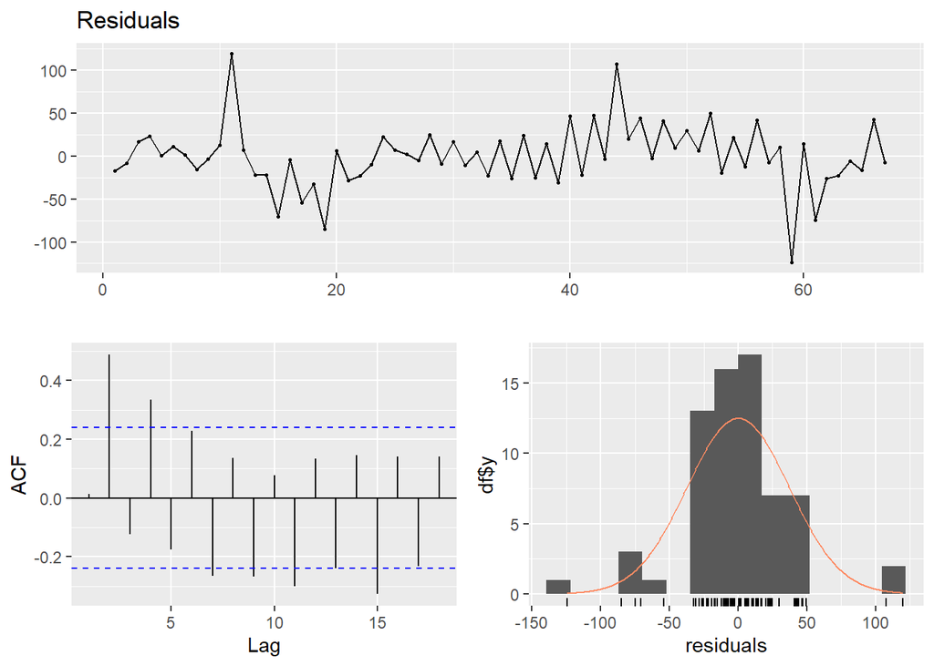

```r
checkresiduals(ARMA.residuals)
```

**Test Serial Autocorrelation**

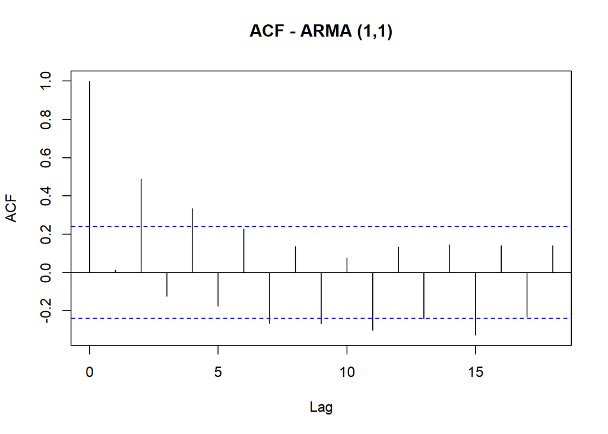

```r
acf(ARMA.residuals,main="ACF - ARMA (1,1)")
```

```r
Box.test(ARMA.residuals,lag=1,type="Ljung-Box")
```

```
##
##  Box-Ljung test
##
## data:  ARMA.residuals
## X-squared = 0.013222, df = 1, p-value = 0.9085
```

Fail to reject the Ho. P-value is > 0.05 indicating that ARMA model does not show residual serial autocorrelation.

**Stationary Test**

```r
adf.test(ARMA.residuals)
```

```
##
##  Augmented Dickey-Fuller Test
##
## data:  ARMA.residuals
## Dickey-Fuller = -2.7737, Lag order = 4, p-value = 0.261
## alternative hypothesis: stationary
```

### ARIMA (1,1,1)

ARIMA would be a better model because we are going to transform our time serie data to stationary, because this model use the differences.

```r
arima1.credit<-arima(data_ev$credit_to_households,order=c(1,1,1))
print(arima1.credit)
```

```
##
## Call:
## arima(x = data_ev$credit_to_households, order = c(1, 1, 1))
##
## Coefficients:
##          ar1      ma1
##       0.9861  -0.7760
## s.e.  0.0193   0.1146
##
## sigma^2 estimated as 1399:  log likelihood = -338.54,  aic = 683.07
```

```r
coeftest(arima1.credit)
```

```
##
## z test of coefficients:
##
##      Estimate Std. Error z value  Pr(>|z|)
## ar1  0.986098   0.019255  51.212 < 2.2e-16 ***
## ma1 -0.775963   0.114600  -6.771 1.279e-11 ***
## ---
## Signif. codes:  0 '***' 0.001 '**' 0.01 '*' 0.05 '.' 0.1 ' ' 1
```

```r
confint(arima1.credit)
```

```
##          2.5 %     97.5 %
## ar1  0.9483586  1.0238371
## ma1 -1.0005755 -0.5513506
```

AR1 explains 0.986 of the Stock Price and ma1 -0.775. Both of the values are significant, we can corroborate with the significance coes, and with the fact that the values are between the acceptance range. The AIC for this model is **683.07**.

#### Diagnosis (Residuals)

```r
arima1.residuals<-(arima1.credit$residuals)
arima1.residuals<-na.omit(arima1.residuals)
```

**Grahping**

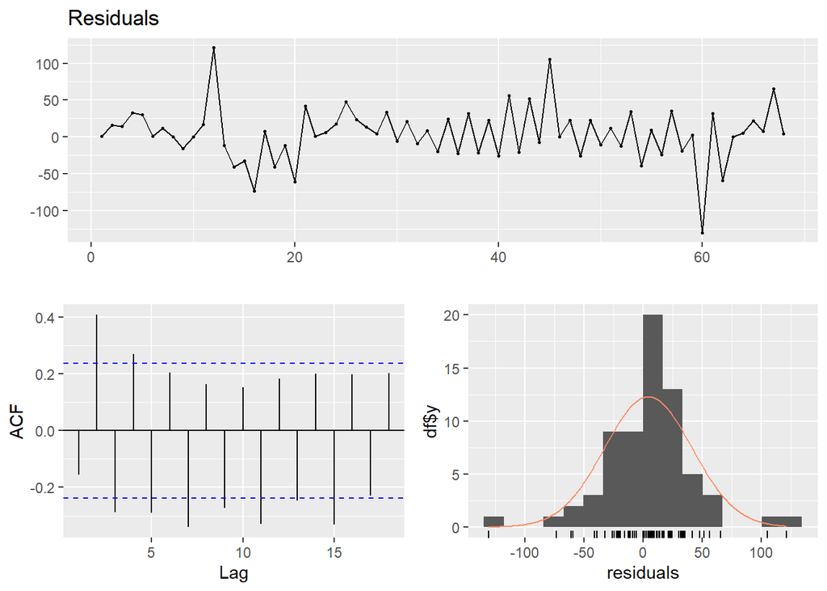

```r
checkresiduals(arima1.residuals)
```

**Test Serial Autocorrelation**

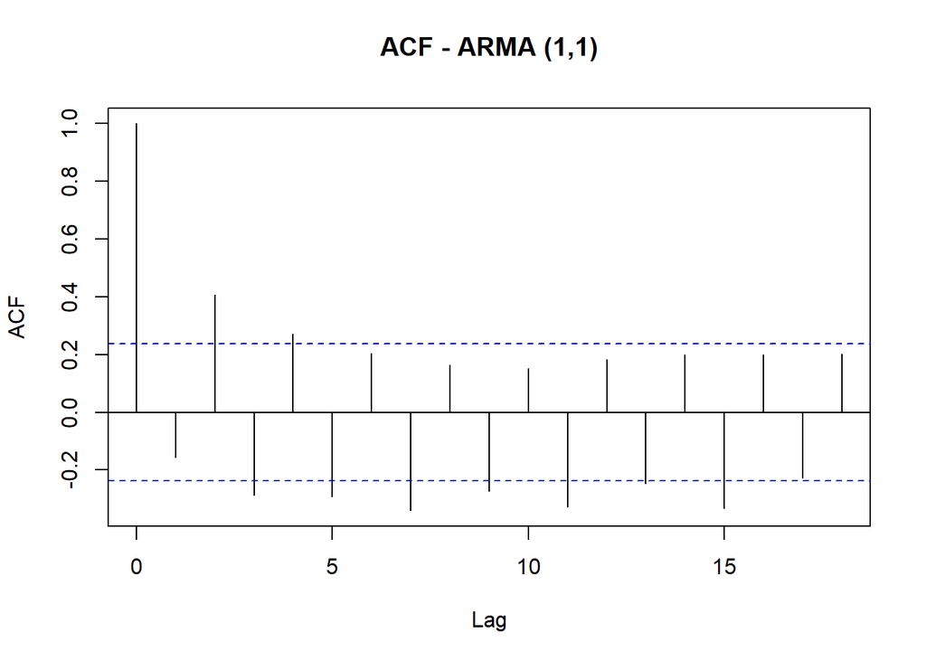

```r
acf(arima1.residuals,main="ACF - ARMA (1,1)")
```

```r
Box.test(arima1.residuals,lag=1,type="Ljung-Box")
```

```
##
##  Box-Ljung test
##
## data:  arima1.residuals
## X-squared = 1.7152, df = 1, p-value = 0.1903
```

Fail to reject the Ho. P-value is > 0.05 indicating that ARMA model does not show residual serial autocorrelation.

**Stationary Test**

```r
adf.test(arima1.residuals)
```

```
##
##  Augmented Dickey-Fuller Test
##
## data:  arima1.residuals
## Dickey-Fuller = -3.3326, Lag order = 4, p-value = 0.074
## alternative hypothesis: stationary
```

The p-value is > 0.05. We can fail to reject Null hypothesis and state that Residuals are non.stationary, but p-value < 0.1, we are going to be flexible and reject the Null hypothesis, Residuals are stationary

### ARIMA (1,2,1)

I decided for this model have d as 2, in order to have differences of 2 lagged periods, so it would be stationary with a high level of confidence

```r
arima2.credit<-arima(data_ev$credit_to_households,order=c(1,2,1))
print(arima2.credit)
```

```
##
## Call:
## arima(x = data_ev$credit_to_households, order = c(1, 2, 1))
##
## Coefficients:
##           ar1     ma1
##       -0.8045  0.1790
## s.e.   0.1430  0.3072
##
## sigma^2 estimated as 1214:  log likelihood = -328.39,  aic = 662.77
```

```r
coeftest(arima2.credit)
```

```
##
## z test of coefficients:
##
##     Estimate Std. Error z value  Pr(>|z|)
## ar1 -0.80452    0.14302 -5.6254 1.851e-08 ***
## ma1  0.17896    0.30721  0.5825    0.5602
## ---
## Signif. codes:  0 '***' 0.001 '**' 0.01 '*' 0.05 '.' 0.1 ' ' 1
```

```r
confint(arima2.credit)
```

```
##          2.5 %     97.5 %
## ar1 -1.0848196 -0.5242108
## ma1 -0.4231541  0.7810826
```

AR1 explains -0.8045 of the Stock Price and ma1 0.1789. AR1 is the only signifcant estimation for the model, with a level of confidence of 99% (p-value <0.05 and estimation values between the acceptance range). The AIC for this model is **662.77**.

#### Diagnosis (Residuals)

```r
arima2.residuals<-(arima2.credit$residuals)
arima2.residuals<-na.omit(arima2.residuals)
```

**Grahping**

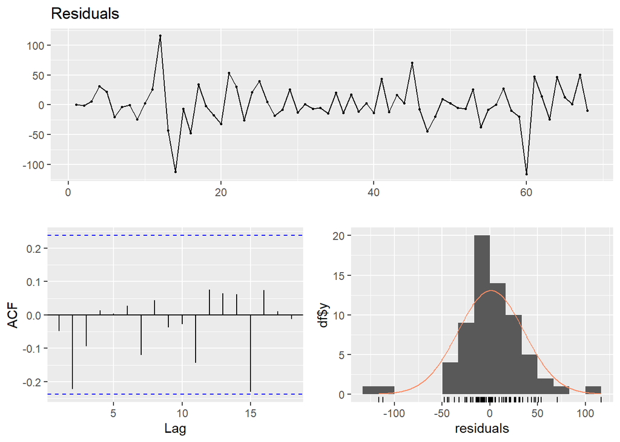

```r
checkresiduals(arima2.residuals)
```

In the graph it looks like residuals follow a normal distribution, and it has no serial correlation. For this model residuals, stationary is more visible

**Test Serial Autocorrelation**

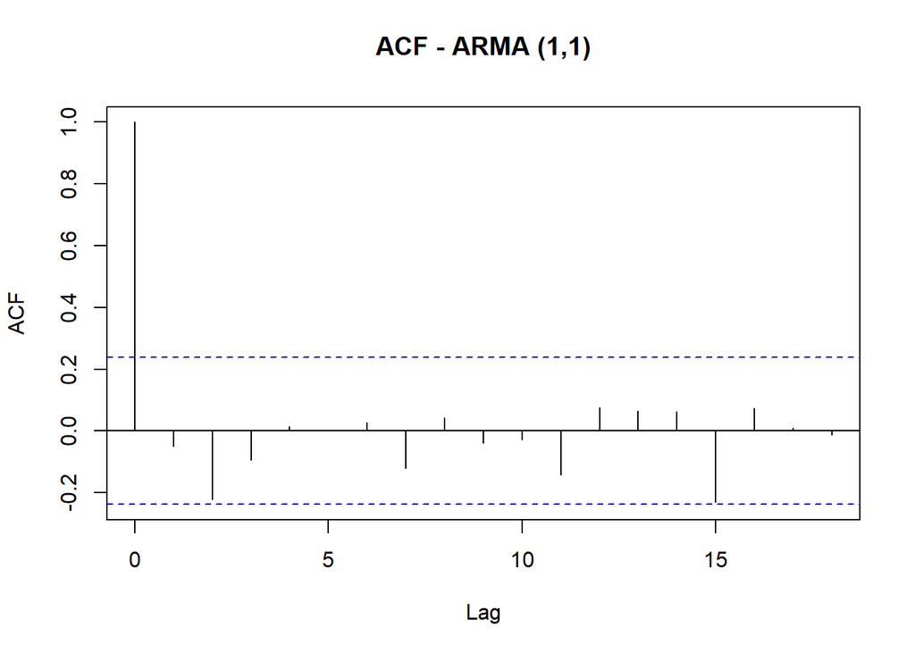

```r
acf(arima2.residuals,main="ACF - ARMA (1,1)")
```

```r
Box.test(arima2.residuals,lag=1,type="Ljung-Box")
```

```
##
##  Box-Ljung test
##
## data:  arima2.residuals
## X-squared = 0.17122, df = 1, p-value = 0.679
```

**Stationary Test**

```r
adf.test(arima2.residuals)
```

```
##
##  Augmented Dickey-Fuller Test
##
## data:  arima2.residuals
## Dickey-Fuller = -4.2984, Lag order = 4, p-value = 0.01
## alternative hypothesis: stationary
```

The p-value is < 0.05. Reject Null Hypothesis. The residuals are stationary

### Selecting Model

After analyzing three models (ARMA 1-1, ARIMA 1-1-1 and ARIMA 1-2-1) and their diagnosis tests, the model with the best accuracy and has better “*scores*” in the diagnosis test was ARIMA 1-2-1 because it has the lowest value and it was stationary at a level of confidence of 95%

### Forecast

```r
arima_forecast<- forecast(arima2.credit,h=5)
arima_forecast
```

```
##    Point Forecast    Lo 80    Hi 80    Lo 95    Hi 95
## 69       4359.458 4314.806 4404.109 4291.169 4427.746
## 70       4418.284 4342.388 4494.180 4302.211 4534.356
## 71       4500.933 4374.945 4626.921 4308.251 4693.615
## 72       4564.416 4389.266 4739.567 4296.547 4832.286
## 73       4643.319 4407.881 4878.756 4283.247 5003.390
```

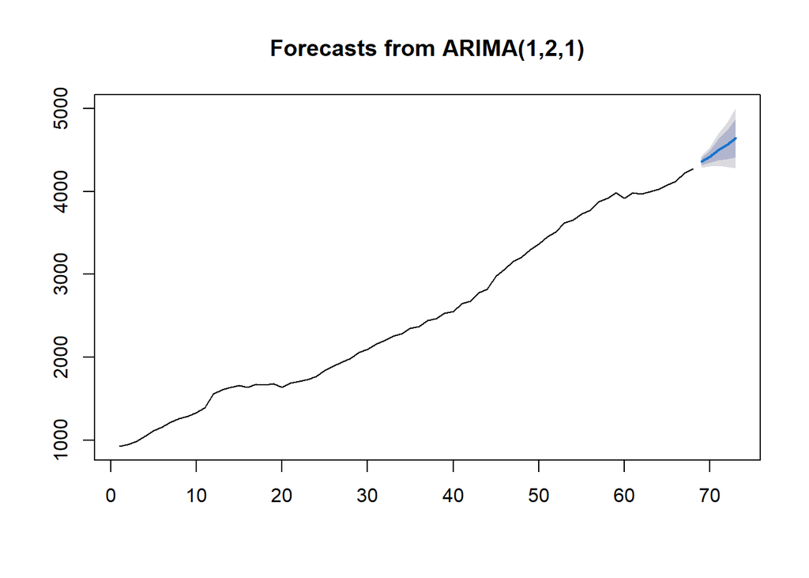

```r
plot(arima_forecast)
```

## Time Series Model 2

### Selection explanatory variables

For the VAR Model, I will select the following variables

- gdp-groth: It is and indicator that shows in a general way how is the economy of a country, so it will reflex the economy of household as well. If the gpd is growing, it means that there is more resources (money) in Mexico, so this means, more money for household, so they are going to spend more money, and need more credit
- unemployment: It people does not have a job, they do not have an income. This variable could be interesting because it could has a positive effect in credit(people is going to need more money because they have no job); or it could have negative effect (people do not want credit because they do not want to pay it )
- consumer_confidence: It help us to understand ow consumers feel about spending their own money. If this one is high, this mean that they would be open to buy more stuff of the companies or invest in them, so they will need credit for this.
- inflation_rate: The inflation rate has an effect on interest rates, so if they are to high, householders are not going to need or want credit.

**Transform to time series format**

```r
inflation<-ts(data_ev$inflation_rate,frequency = 4,start = c(2005,1))
gdp<-ts(data_ev$gdp_growth,frequency = 4,start = c(2005,1))
unemployment<-ts(data_ev$unemployment,frequency = 4,start = c(2005,1))
consumer<-ts(data_ev$consumer_confidence,frequency = 4,start = c(2005,1))
```

### Plots

[figure not shown]

```r
par(mfrow=c(2,2))
plot(data_ev$date,data_ev$inflation_rate,type="l",col="blue",lwd=2,xlab="Date",ylab="Inflation (%)",main="Inflation Rate")
plot(data_ev$date,data_ev$gdp_growth,type="l",col="blue",lwd=2,xlab="Date",ylab="Growth(%)",main="GDP growth")
plot(data_ev$date,data_ev$unemployment,type="l",col="blue",lwd=2,xlab="Date",ylab="Unemployment",main="Unemployment Rate")
plot(data_ev$date,data_ev$unemployment,type="l",col="blue",lwd=2,xlab="Date",ylab="Score",main="Consumer Confidence")
```

### VAR Model

#### Combining Time series

```r
creditVAR<-cbind(credits,inflation,gdp,unemployment,consumer)
colnames(creditVAR)<-cbind("credit","inflation","gdp","unemployment","consumer_sen")
```

#### Lag selection

```r
lag_selection<-VARselect(creditVAR,lag.max=5,type="const",season = 4)
lag_selection$selection
```

```
## AIC(n)  HQ(n)  SC(n) FPE(n)
##      5      5      1      5
```

```r
lag_selection$criteria
```

```
##                  1           2           3            4           5
## AIC(n)    11.07170    10.81317    10.57239     9.732325     9.36524
## HQ(n)     11.67378    11.74973    11.84344    11.337859    11.30526
## SC(n)     12.60251    13.19443    13.80410    13.814487    14.29785
## FPE(n) 64960.79440 51579.11706 43009.04598 20630.666181 16970.05789
```

```r
VAR_model1<-VAR(creditVAR,p=1,type="const",season=5)
summary(VAR_model1)
```

```
##
## VAR Estimation Results:
## =========================
## Endogenous variables: credit, inflation, gdp, unemployment, consumer_sen
## Deterministic variables: const
## Sample size: 67
## Log Likelihood: -825.411
## Roots of the characteristic polynomial:
## 1.004 0.8033 0.6162 0.5235 0.0811
## Call:
## VAR(y = creditVAR, p = 1, type = "const", season = 5L)
##
##
## Estimation results for equation credit:
## =======================================
## credit = credit.l1 + inflation.l1 + gdp.l1 + unemployment.l1 + consumer_sen.l1 + const + sd1 + sd2 + sd3 + sd4
##
##                   Estimate Std. Error t value Pr(>|t|)
## credit.l1         1.004216   0.004478 224.257  < 2e-16 ***
## inflation.l1     -2.881138   2.644612  -1.089  0.28055
## gdp.l1            2.918284   1.044327   2.794  0.00707 **
## unemployment.l1 -15.996193   5.964264  -2.682  0.00956 **
## consumer_sen.l1  -1.964077   1.303488  -1.507  0.13739
## const           184.815576  67.804855   2.726  0.00851 **
## sd1               6.441447  13.681709   0.471  0.63958
## sd2              12.821154  13.522887   0.948  0.34708
## sd3               2.480859  13.512101   0.184  0.85498
## sd4               4.656766  13.652591   0.341  0.73429
## ---
## Signif. codes:  0 '***' 0.001 '**' 0.01 '*' 0.05 '.' 0.1 ' ' 1
##
##
## Residual standard error: 34.68 on 57 degrees of freedom
## Multiple R-Squared: 0.999,   Adjusted R-squared: 0.9988
## F-statistic:  6264 on 9 and 57 DF,  p-value: < 2.2e-16
##
##
## Estimation results for equation inflation:
## ==========================================
## inflation = credit.l1 + inflation.l1 + gdp.l1 + unemployment.l1 + consumer_sen.l1 + const + sd1 + sd2 + sd3 + sd4
```

[output cut: 94 more lines]

```
## Covariance matrix of residuals:
##                 credit inflation     gdp unemployment consumer_sen
## credit       1202.9902   -0.8268 36.9491       1.3834      10.0221
## inflation      -0.8268    3.0645  1.1457       0.2065      -0.1587
## gdp            36.9491    1.1457 16.3742      -0.4354       4.4915
## unemployment    1.3834    0.2065 -0.4354       0.3432      -0.2726
## consumer_sen   10.0221   -0.1587  4.4915      -0.2726       5.9867
##
## Correlation matrix of residuals:
##                credit inflation     gdp unemployment consumer_sen
## credit        1.00000  -0.01362  0.2633      0.06809      0.11810
## inflation    -0.01362   1.00000  0.1617      0.20139     -0.03705
## gdp           0.26327   0.16174  1.0000     -0.18368      0.45365
## unemployment  0.06809   0.20139 -0.1837      1.00000     -0.19020
## consumer_sen  0.11810  -0.03705  0.4536     -0.19020      1.00000
```

**Credit:** For this regression model, lagged GDP, lagged unemployment, and lagged credit (all of them 1) were significant. Credit.l1 increase the credit to household) by 1.004, gdp by 2.91 and unemployment decrease the credit by 15.996. We have a constant of 184.81

**Inflation:** For this model, any variable were significant. This could mean that any of the variables selected explain the inflation, but it explained by other factors. The constant is significant by 90%, and but the effect is very low

**GDP:** This one is just explained by itself lagged one period. It increase it by 0.486

**Consumer Confidence:** For this model just the lagged variable and a constant are significant. Consumer_sen.l1 increase the depedent variable in 0.756, and the constant is 11.44

#### Residuals

```r
VAR_model1_credit.r<-residuals(VAR_model1,credit)
```

### Diagnosis Test

#### Stationary

```r
adf.test(as.vector(VAR_model1_credit.r))
```

```
##
##  Augmented Dickey-Fuller Test
##
## data:  as.vector(VAR_model1_credit.r)
## Dickey-Fuller = -6.4462, Lag order = 6, p-value = 0.01
## alternative hypothesis: stationary
```

Residuals are stationary. P-value < 0.05. Reject NULL hypothesis

#### Serial Autocorrelation

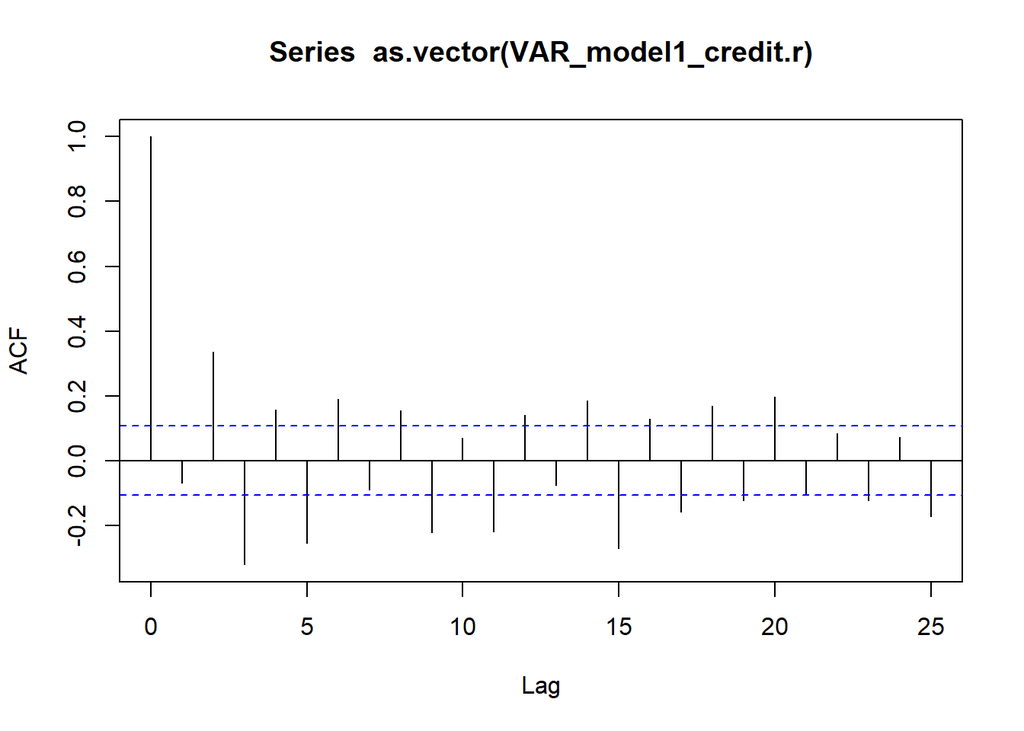

```r
acf(as.vector(VAR_model1_credit.r))
```

```r
Box.test(as.vector(VAR_model1_credit.r),lag=1,type="Ljung-Box")
```

```
##
##  Box-Ljung test
##
## data:  as.vector(VAR_model1_credit.r)
## X-squared = 1.6154, df = 1, p-value = 0.2037
```

Fail to reject the Ho. P-value is > 0.05 indicating that VAR residual’s model does not show residual serial autocorrelation.

### Granger Causality Test

```r
granger_credit<-causality(VAR_model1,cause="credit")
granger_credit
```

```
## $Granger
##
##  Granger causality H0: credit do not Granger-cause inflation gdp
##  unemployment consumer_sen
##
## data:  VAR object VAR_model1
## F-Test = 0.94073, df1 = 4, df2 = 285, p-value = 0.4407
##
##
## $Instant
##
##  H0: No instantaneous causality between: credit and inflation gdp
##  unemployment consumer_sen
##
## data:  VAR object VAR_model1
## Chi-squared = 5.5913, df = 4, p-value = 0.2318
```

**Granger-cause** : p-value>0.05 we fail to reject the Ho. There is no granger causality between variables

**Instant Causality**: p-value>0.05. We fail to reject the Ho. There is no instant causality between variables

### Forecast

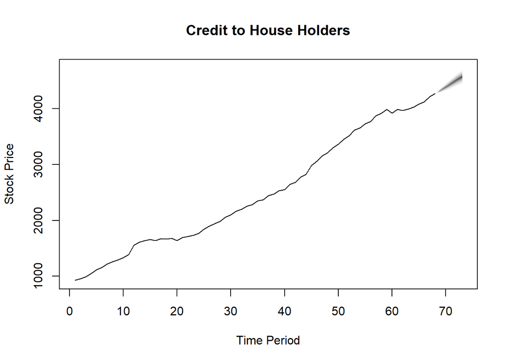

```r
forecast_1<-predict(VAR_model1,n.ahead=5,ci=0.95) ### forecast for the next four quarters
fanchart(forecast_1,names="credit",main="Credit to House Holders",xlab="Time Period",ylab="Stock Price")
```

```r
forecast_1
```

```
## $credit
##          fcst    lower    upper        CI
## [1,] 4331.194 4263.214 4399.173  67.97968
## [2,] 4388.309 4284.610 4492.008 103.69880
## [3,] 4449.470 4314.664 4584.277 134.80645
## [4,] 4516.853 4354.048 4679.657 162.80458
## [5,] 4571.574 4383.416 4759.731 188.15744
##
## $inflation
##          fcst     lower    upper       CI
## [1,] 2.158759 -1.272293 5.589810 3.431051
## [2,] 1.969944 -1.500051 5.439940 3.469995
## [3,] 2.379756 -1.104379 5.863890 3.484135
## [4,] 1.592062 -1.898640 5.082764 3.490702
## [5,] 2.307230 -1.186742 5.801201 3.493971
##
## $gdp
##            fcst      lower    upper       CI
## [1,]  0.2468187  -7.684174 8.177811 7.930992
## [2,] -0.5826895  -9.351870 8.186491 8.769181
## [3,]  0.8186402  -8.110890 9.748170 8.929530
## [4,] -1.6370003 -10.607089 7.333089 8.970089
## [5,] -2.0571658 -11.047810 6.933478 8.990644
##
## $unemployment
##          fcst    lower    upper       CI
## [1,] 3.063835 1.915684 4.211985 1.148151
## [2,] 3.063303 1.631506 4.495100 1.431797
## [3,] 3.333729 1.775207 4.892250 1.558522
## [4,] 3.380154 1.753317 5.006991 1.626837
## [5,] 3.335662 1.669499 5.001825 1.666163
##
## $consumer_sen
##          fcst    lower    upper       CI
## [1,] 43.87447 39.07887 48.67007 4.795600
## [2,] 44.26521 38.06517 50.46526 6.200044
## [3,] 43.75596 36.76287 50.74906 6.993093
## [4,] 42.21105 34.73487 49.68723 7.476179
## [5,] 42.14086 34.36112 49.92059 7.779736
```

# Conclusions and Recomendations

## Main insights

With both models we could appreciate that there will be a growth for this indicator, such as trends indicates. In the case of VAR analysis it was interesting that unemployment was a significant variable and it has big impact in the credit to householders. This mean that if householders do not have a job they won’t want a credit. GDP growth also is interesting because, it means that meanwhile the country is generating resources, householders will need more credit.

## Recommendations

We have to remember that Credit Card is one way to get credit for household

- Focus marketing on people with a job or an income, this people would be more open to get a credit card, and also will be able to pay their bills.
- Take advantage of the GDP growing. Check often this indicator, because this would mean that more people would be open to get and use a Credit Card
- For your estimations in financial and accounting statements and others, consider 184.81 as constant (Constant in VAR MODEL/credit) this will help the company would have a better estimation about the credit of house holders and how this one is behaving

# References

- Euromonitor International. (2022, julio). Households: Mexico: Country Report. Passport. Recuperado 11 de septiembre de 2022, de https://www.portal.euromonitor.com/portal/?23gAoWUxDNWsBx7Lh%2b1e%2f4tC5ukb3NTju1BTbUmxXIh0snV7eQ4ndg%3d%3d
- Mexico Household credit, billion currency units, June, 2022 - data, chart. (s. f.). TheGlobalEconomy.com. Recuperado 11 de septiembre de 2022, de https://www.theglobaleconomy.com/Mexico/household_credit/
- Tableau. (s. f.). Time Series Analysis: Definition, Types, Techniques, and When It’s Used. Recuperado 10 de septiembre de 2022, de https://www.tableau.com/learn/articles/time-series-analysis